# LAC data supplemental information

Tse Yang Lim

2024-04-15

### Identifying first positive results for each case

The full dataset contains 330034 positive test results, each with individual and infection episode identifiers. Of these, 50542 were non-first or repeat positives for a given infection episode; dropping these left 279492 results reporting the first Ct value for each infection episode.

A further 29 results include reported Ct values of exactly 45, distinctly above the highest other Ct values reported (approx. 40) and likely indicating an erroneous result. These results were dropped as well, leaving 279463 results in the final sample for this analysis.

### Sample demographics

The final sample includes positive results from 273661 individuals of age 0 to 90+, with most between approx. 15-60. The age distribution of positive individuals was consistent over the course of the pandemic. Slightly over half of the positive results were from females. Weekly totals of positive results varied over the course of the pandemic, somewhat reflecting the multiple waves of infections observed more broadly, especially the 2021 and 2022 Alpha / Omicron winter surges; sample sizes were relatively smaller from 2022 onward, possibly reflecting increased availability of self-administered rapid antigen tests.

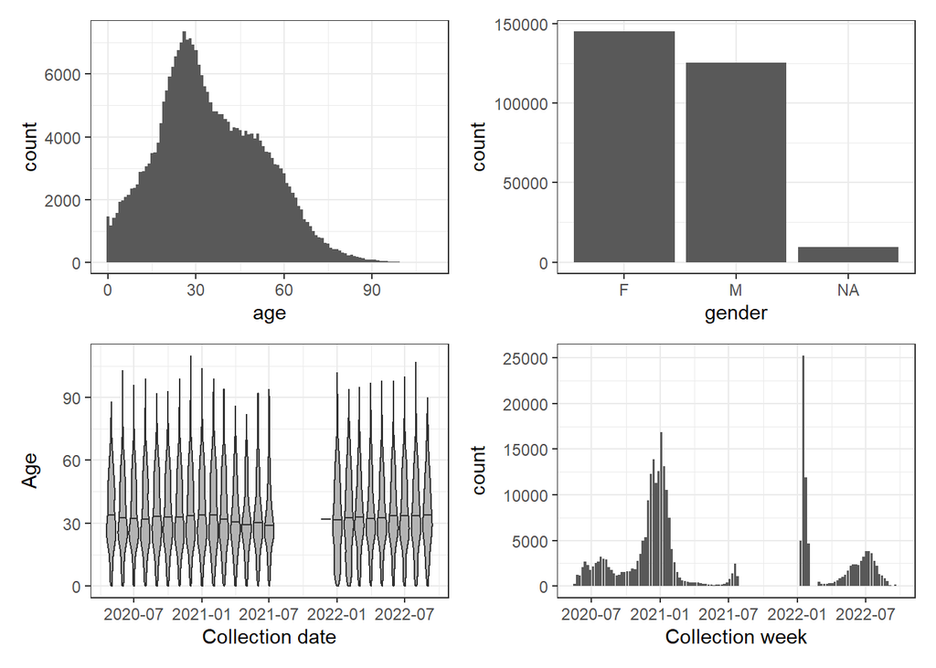

### Assays and Ct values

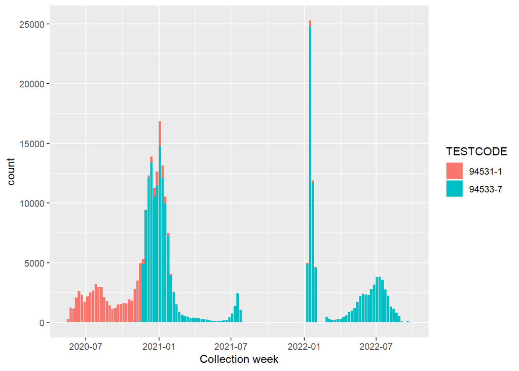

For LOINC 94531-1 results, we used the the lower of the N1/N2 Ct values (N2 in ~90% of cases). Recorded N1/N2 Ct values range from approx. 6-39, while the SC2N Ct values range from approx. 8-37.

| TESTCODE | min_Ct | median_Ct | max_Ct |
| --- | --- | --- | --- |
| 94531-1 | 6.343580 | 24.08012 | 38.90409 |
| 94533-7 | 7.920967 | 21.45457 | 37.08066 |

### Symptom status and testing delays

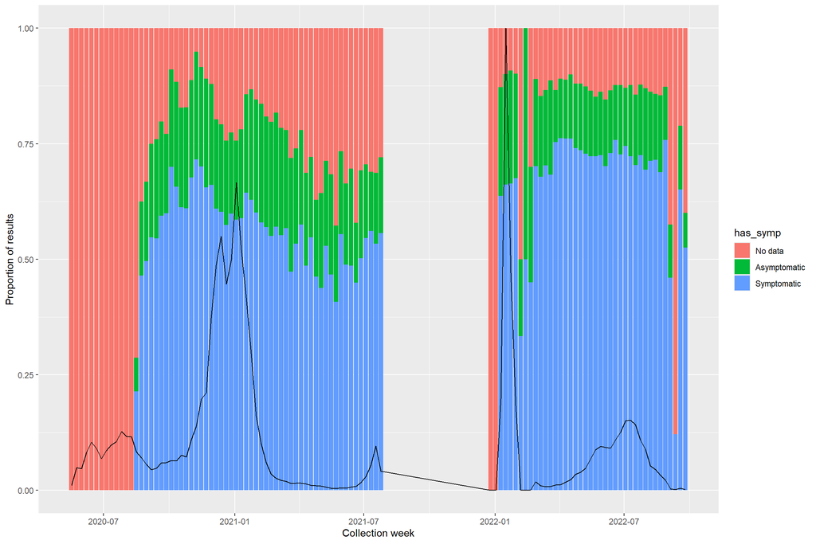

We calculate testing delays as the difference between the time of specimen collection and symptom onset. Plotting the distribution of testing delays, as expected, the vast majority are short (a few days). However, there are small clusters of testing delays at approx. 365 and 730 days, i.e. 1 and 2 years. We assume that these longer delays reflect data entry errors in recording symptom onset dates, and thus correct them by adjusting the onset dates by +1 or +2 years.

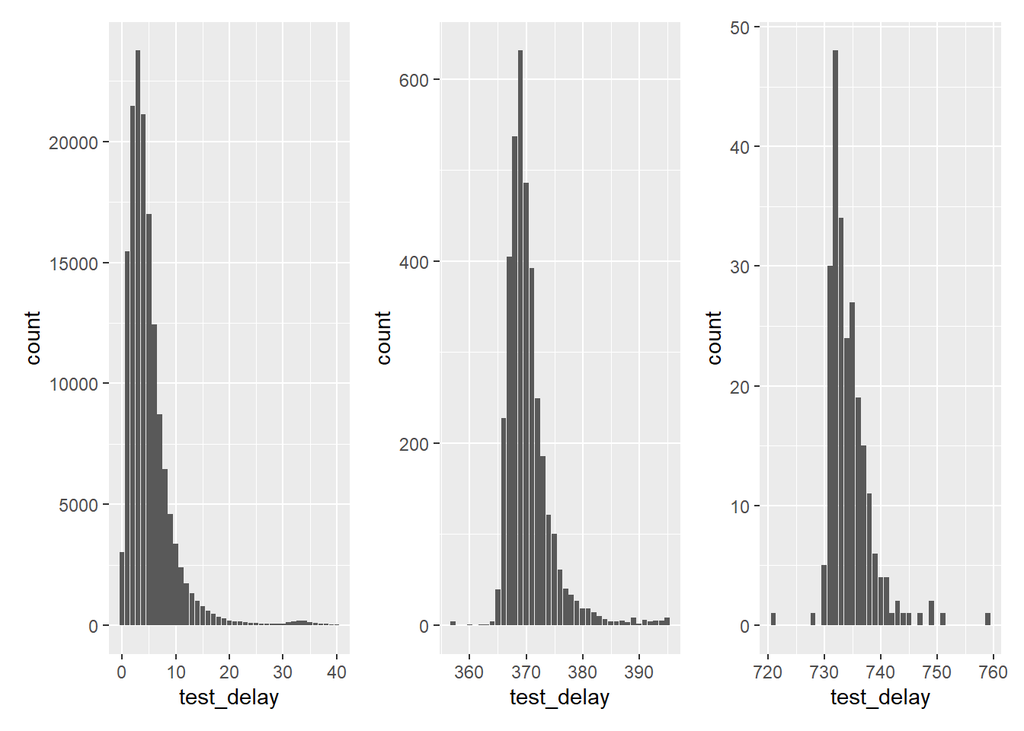

After correcting for these presumptive data entry errors, while a handful of long recorded testing delays remain, the majority of testing delays fall between 1 and 10 days, with a peak of around 2-4 days between symptom onset and specimen collection.

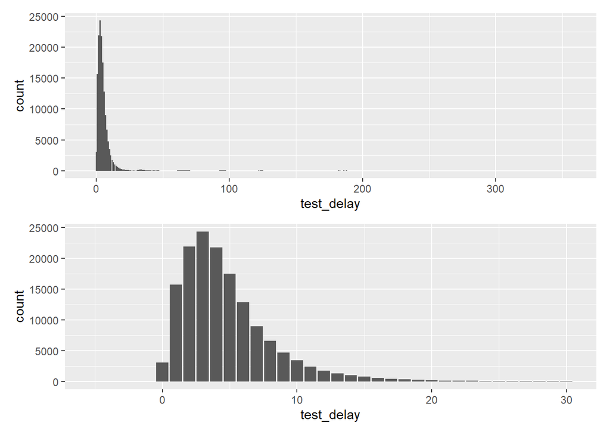

The distribution of testing delays is fairly consistent over time, with no strong month-to-month variation. Average testing delays were slightly longer in 2020 and during the two major winter peaks, potentially indicating some test capacity limitations.

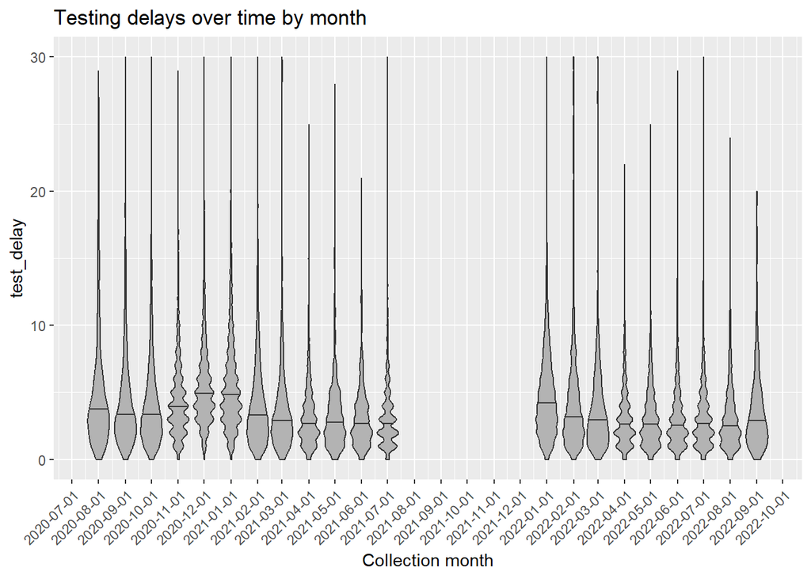

### Ct by test delay

For symptomatic cases, we can examine the distribution of Ct values by testing delay (time from onset of symptoms to sample collection). As symptom onset typically coincides with peak viral load (though may be slightly earlier in people with past immunological exposure), this distribution should approximate the clearance phase of the viral load trajectory, sampled across thousands of individuals.

While there is very wide variation in individual Ct values over time since symptom onset, overall there is some noticeable decline, with lower viral loads the longer the testing delay. This pattern is consistent over the course of the pandemic, though clearance times appear to be shortening in its later stages.

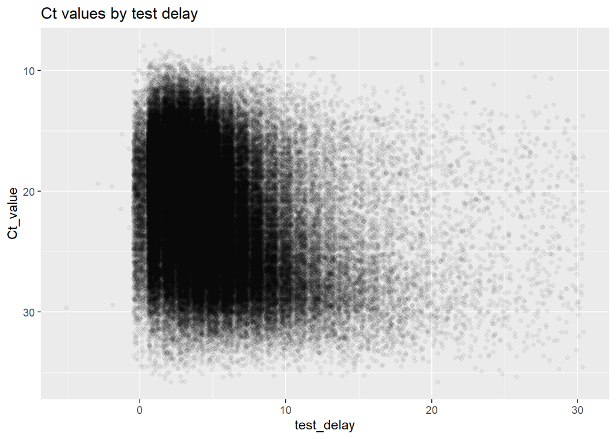

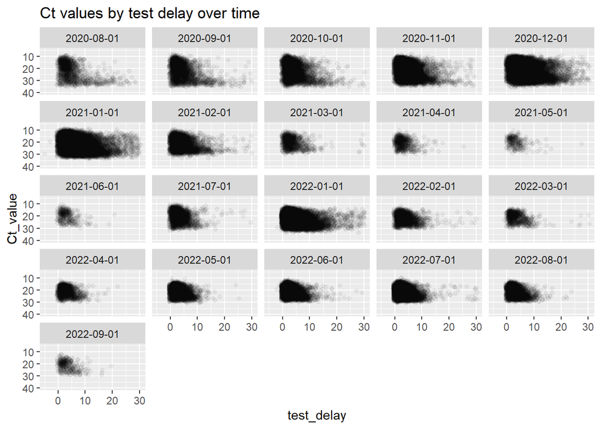

Stratifying individual results by past immunological exposure to SARS-CoV-2 (through vaccination or past infection) yields a potential explanation for this pattern. Consistent with previous observations, vaccinated or recovered individuals clear infections slightly faster, with more rapid declines in viral load. Over the course of the pandemic, the majority of individuals testing positive shift from being immunologically naive early on to previously infected or vaccinated later on, resulting in the shift in the aggregated distribution.

The approximation of viral kinetics and the shift resulting from immunological exposure are even clearer when we include repeat tests (previously excluded for purposes of nowcasting analysis), as these comprise a substantial fraction of the observations later in individuals’ viral load trajectories (i.e. the right tail of the distribution).

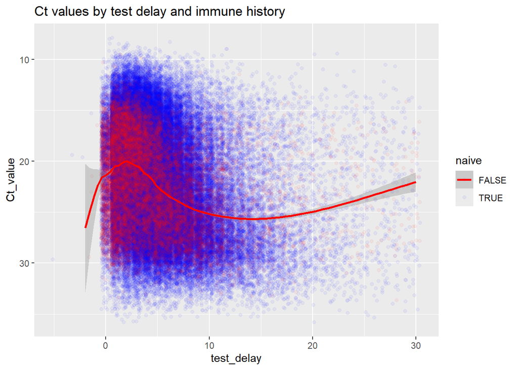

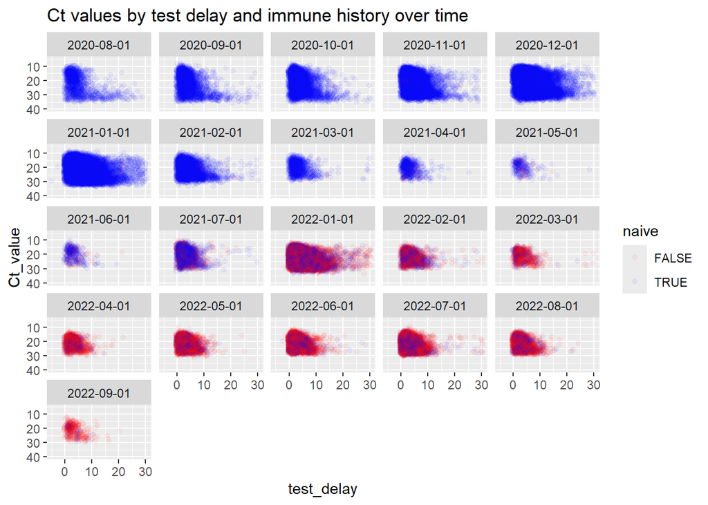

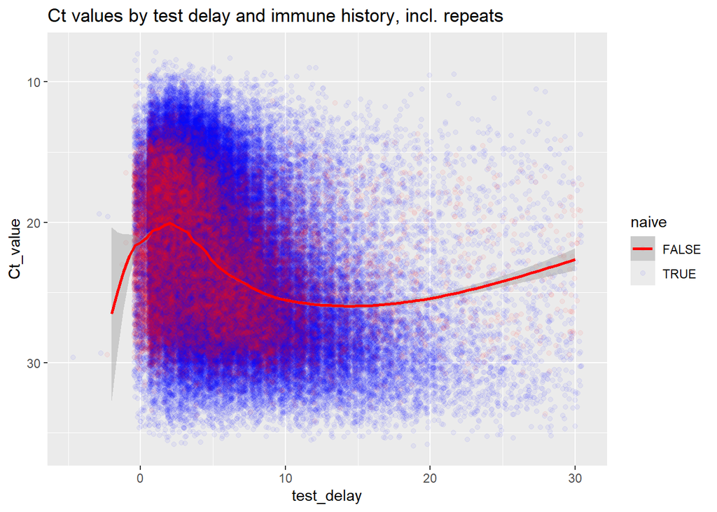

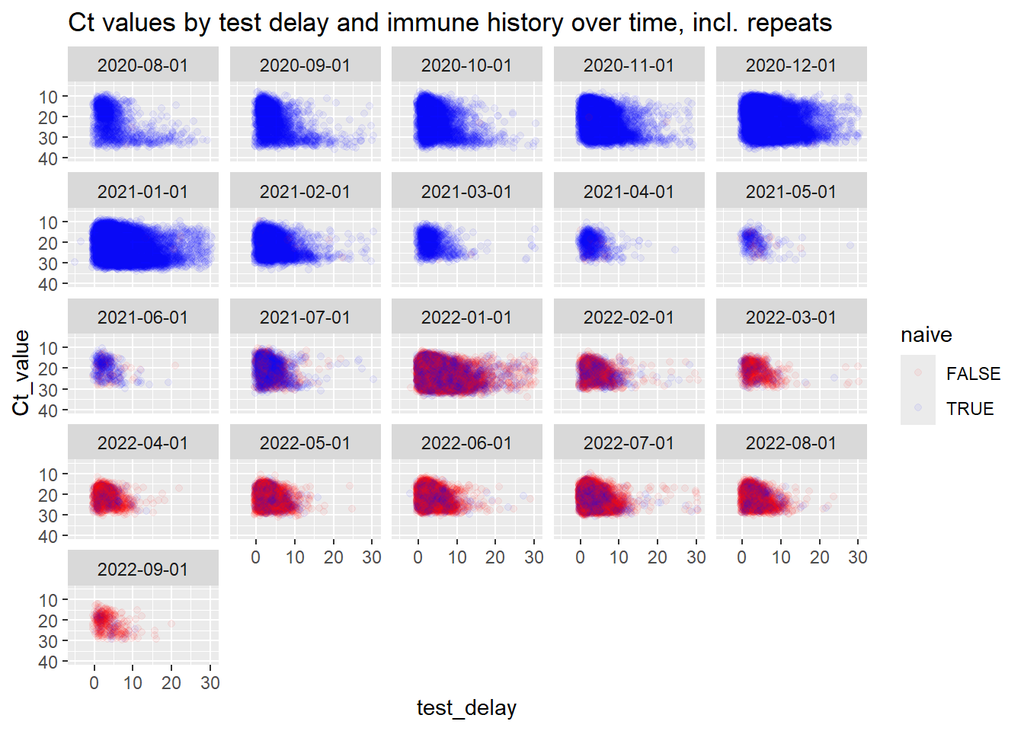